# Analyse des Séries Temporelles - Préparation des Données

# Rapport : Prévision de la Consommation Électrique avec et sans Covariables

## 1. Introduction

### Objectif principal

L’objectif de ce projet est de prévoir la consommation électrique pour une période future (17 février 2010) en utilisant différents modèles de prévision, avec et sans l’intégration de la température extérieure comme covariable.

### Méthodologie

1. Exploration et transformation des données.
2. Tests de plusieurs modèles (régression, ARIMA, Holt-Winters, RNN, XGBoost).
3. Comparaison des performances en termes de RMSE sur les données TEST.
4. Prévisions des données futures.

## 2. Données et Prétraitement

### Données disponibles

- **Consommation électrique (kW)** : Donnée principale à modéliser.
- **Température extérieure (°C)** : Covariable explicative.

### Chargement des Bibliothèques

```r
library(fpp)          # Méthodes de prévision
library(readxl)       # Pour lire les fichiers Excel
library(lubridate)    # Gestion des dates et heures
library(forecast)     # Analyse des séries temporelles
library(ggplot2)      # Visualisation
```

### Chargement et Exploration des Données

```r
# Charger les données depuis un fichier Excel
data <- readxl::read_excel("Elec-train.xlsx")

# Afficher la structure des données
str(data)
```

```
tibble [4,603 × 3] (S3: tbl_df/tbl/data.frame)
 $ Timestamp : chr [1:4603] "40179.052083333336" "1/1/2010 1:30" "1/1/2010 1:45" "1/1/2010 2:00" ...
 $ Power (kW): num [1:4603] 165 152 147 154 154 ...
 $ Temp (C°) : num [1:4603] 10.6 10.6 10.6 10.6 10.6 ...
```

### Prétraitement des Données

```r
# Conversion des dates au bon format
data$Timestamp[1] <- "1/1/2010 1:15"  # Correction manuelle du premier enregistrement
data$Timestamp <- mdy_hm(data$Timestamp)

# Renommage des colonnes
colnames(data) <- c("date", "electricity_consumption", "outdoor_temperature")

# Vérification des colonnes renommées
head(data)
```

| date | electricity_consumption | outdoor_temperature |
| --- | --- | --- |
| 2010-01-01 01:15:00 | 165.1 | 10.55556 |
| 2010-01-01 01:30:00 | 151.6 | 10.55556 |
| 2010-01-01 01:45:00 | 146.9 | 10.55556 |
| 2010-01-01 02:00:00 | 153.7 | 10.55556 |
| 2010-01-01 02:15:00 | 153.8 | 10.55556 |
| 2010-01-01 02:30:00 | 159.0 | 10.55556 |

### Conversion en Séries Temporelles

Les données initiales sont brutes et nécessitent une transformation en séries temporelles adaptées à l’analyse. Deux séries ont été créées : une pour la consommation d’énergie et une autre pour la température extérieure. Les données de consommation sont collectées toutes les 15 minutes, couvrant la période du 1er janvier 2010 à 01:15 au 16 février 2010 à 23:45. Les données de température, quant à elles, s’étendent du 1er janvier 2010 au 17 février 2010.

Étant donné que la prévision doit porter sur une journée complète (le 17 février 2010), nous avons choisi une fréquence de 96 observations par jour, correspondant aux 96 quarts d’heure. De plus, la série temporelle commence au jour 1, au 5ᵉ quart d’heure, en raison de la disponibilité des données à partir de 01:15.

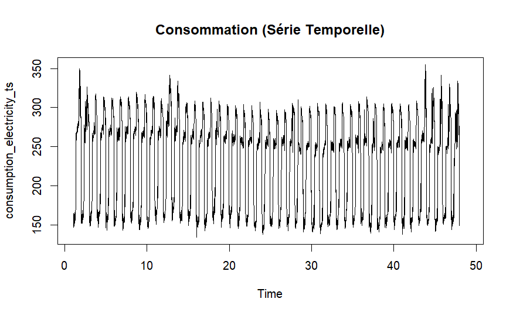

```r
# Création de la série temporelle pour la consommation
consumption_electricity_ts <- ts(
  data$electricity_consumption,
  start = c(1, 5),     # Début : jour 1, 5e quart d'heure
  frequency = 96       # 96 quarts d'heure par jour
)

# Création de la série temporelle pour la température
temperature_ts <- ts(
  data$outdoor_temperature,
  start = c(1, 5),
  frequency = 96
)

# Visualisation des séries temporelles
plot(consumption_electricity_ts, main = "Consommation (Série Temporelle)")
```

### Division en Entraînement et Test

- Entraînement : Jusqu’au 15 février 2010 inclus.
- Test : 16 février 2010.
- Prévisions futures : 17 février 2010.

```r
# Données d'entraînement (16 premiers jours)
train_consumption_electricity <- window(consumption_electricity_ts, start = c(1, 5), end = c(46, 95))
train_temperature_ts <- window(temperature_ts, start = c(1, 5), end = c(46, 95))

# Données de test (17e jour)
test_consumption_electricity <- window(consumption_electricity_ts, start = c(46, 96), end = c(47, 95))
test_temperature_ts <- window(temperature_ts, start = c(46, 96), end = c(47, 95))

# Données de prévision (18e jour)
predict_consumption_electricity <- window(consumption_electricity_ts, start = c(47, 96), end = c(48, 95))
predict_temperature <- window(temperature_ts, start = c(47, 96), end = c(48, 95))
```

### Analyse Saisonnalité

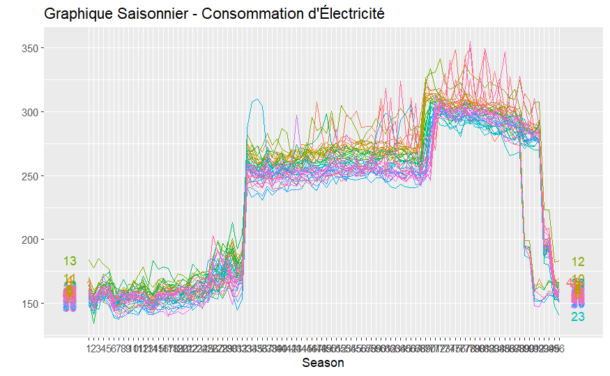

```r
# Visualisation de la saisonnalité sur les données d'entraînement
ggseasonplot(
  train_consumption_electricity,
  year.labels = TRUE,
  year.labels.left = TRUE,
  main = "Graphique Saisonnier - Consommation d'Électricité"
)
```

# Modèles sans covariables

Pour évaluer mes modèles, j’ai choisi de me baser sur le RMSE (Root Mean Square Error) calculé sur les données de test. Cette métrique est particulièrement pertinente car elle permet de mesurer la précision des prévisions en se rapprochant au mieux des conditions réelles de notre objectif : prédire la consommation électrique sur une journée complète, comme celle couverte par la période des données de test.

## Modélisation - Régression Linéaire

```r
# Création de la variable temporelle
time_train <- 1:length(train_consumption_electricity)

# Ajustement du modèle linéaire
lm_model <- lm(train_consumption_electricity ~ time_train)
summary(lm_model)  # Résumé du modèle
```

```
Call:
lm(formula = train_consumption_electricity ~ time_train)

Residuals:
   Min     1Q Median     3Q    Max
-99.36 -68.35  23.66  44.32 128.28

Coefficients:
              Estimate Std. Error t value Pr(>|t|)
(Intercept)  2.370e+02  1.729e+00 137.109  < 2e-16 ***
time_train  -2.488e-03  6.787e-04  -3.666 0.000249 ***
---
Signif. codes:  0 ‘***’ 0.001 ‘**’ 0.01 ‘*’ 0.05 ‘.’ 0.1 ‘ ’ 1

Residual standard error: 57.4 on 4409 degrees of freedom
Multiple R-squared:  0.003039,  Adjusted R-squared:  0.002813
F-statistic: 13.44 on 1 and 4409 DF,  p-value: 0.0002492
```

```r
# Prédictions pour l'ensemble de test
time_test <- (length(train_consumption_electricity) + 1):(length(train_consumption_electricity) + length(test_consumption_electricity))
test_predictions <- predict(lm_model, newdata = data.frame(time_train = time_test))

# Prédictions pour l'ensemble de prévision
time_forecast <- (length(train_consumption_electricity) + length(test_consumption_electricity) + 1):(length(train_consumption_electricity) + length(test_consumption_electricity) + length(predict_consumption_electricity))
forecast_predictions <- predict(lm_model, newdata = data.frame(time_train = time_forecast))

# Calcul du RMSE pour l'ensemble de test
rmse_linear <- sqrt(mean((test_consumption_electricity - test_predictions)^2))
cat("RMSE pour le modèle linéaire (test):", rmse_linear, "\n")
```

```
RMSE pour le modèle linéaire (test): 61.31617
```

## Modélisation - Lissage Exponentiel

```r
# Modèle 1 : Lissage exponentiel simple
ses_model <- ses(train_consumption_electricity, h = 96)
ses_forecast <- forecast(ses_model, h = length(test_consumption_electricity))
rmse_ses <- sqrt(mean((test_consumption_electricity - ses_forecast$mean)^2))
cat("RMSE pour le lissage exponentiel simple:", rmse_ses, "\n")
```

```
RMSE pour le lissage exponentiel simple: 88.88736
```

## Modélisation - Lissage de Holt sans saisonnalité

```r
holt_model <- holt(train_consumption_electricity, h = 96)
holt_forecast <- forecast(holt_model, h = length(test_consumption_electricity))
rmse_holt <- sqrt(mean((test_consumption_electricity - holt_forecast$mean)^2))
cat("RMSE pour le modèle Holt sans saisonnalité:", rmse_holt, "\n")
```

```
RMSE pour le modèle Holt sans saisonnalité: 88.82056
```

## Modélisation - Holt-Winters avec saisonnalité additive

```r
hw_model_add <- HoltWinters(train_consumption_electricity, seasonal = "additive")
summary(hw_model_add)
```

```
             Length Class  Mode
fitted       17260  mts    numeric
x             4411  ts     numeric
alpha            1  -none- numeric
beta             1  -none- numeric
gamma            1  -none- numeric
coefficients    98  -none- numeric
seasonal         1  -none- character
SSE              1  -none- numeric
call             3  -none- call
```

```r
hw_forecast_add <- forecast(hw_model_add, h = length(test_consumption_electricity))
rmse_hw_add <- sqrt(mean((test_consumption_electricity - hw_forecast_add$mean)^2))
cat("RMSE pour Holt-Winters Additif:", rmse_hw_add, "\n")
```

```
RMSE pour Holt-Winters Additif: 16.86543
```

Bien que l’effet saisonnier de la série temporelle de consommation ne soit pas constant (il varie d’un jour à l’autre), ce modèle a fourni des résultats relativement acceptables, avec un RMSE de 16,86. Cela montre qu’il parvient à capturer une partie des variations saisonnières, même si elles ne sont pas totalement régulières.

## Modélisation - Holt-Winters avec saisonnalité multiplicative

```r
hw_model_mult <- HoltWinters(train_consumption_electricity, seasonal = "multiplicative")
summary(hw_model_mult)
```

```
             Length Class  Mode
fitted       17260  mts    numeric
x             4411  ts     numeric
alpha            1  -none- numeric
beta             1  -none- numeric
gamma            1  -none- numeric
coefficients    98  -none- numeric
seasonal         1  -none- character
SSE              1  -none- numeric
call             3  -none- call
```

```r
hw_forecast_mult <- forecast(hw_model_mult, h = length(test_consumption_electricity))
rmse_hw_mult <- sqrt(mean((test_consumption_electricity - hw_forecast_mult$mean)^2))
cat("RMSE pour Holt-Winters Multiplicatif:", rmse_hw_mult, "\n")
```

```
RMSE pour Holt-Winters Multiplicatif: 13.92376
```

Sur la base de mes données, ce modèle est censé offrir les meilleures performances, car il prend en compte les variations de l’effet saisonnier. Cette hypothèse a été confirmée lors de son application, avec un RMSE de 13,92, ce qui en fait l’un des modèles les plus performants de cette analyse.

## Modélisation - ARIMA

```r
# Début de la mesure du temps d'exécution
start_time <- Sys.time()
# Ajustement automatique du modèle ARIMA
auto_arima <- auto.arima(train_consumption_electricity)
# Fin de la mesure du temps d'exécution
end_time <- Sys.time()

summary(auto_arima)
```

```
Series: train_consumption_electricity
ARIMA(5,0,0)(0,1,0)[96]

Coefficients:
         ar1     ar2     ar3      ar4     ar5
      0.7198  0.0611  0.1086  -0.2604  0.1231
s.e.  0.0151  0.0182  0.0182   0.0183  0.0153

sigma^2 = 112.7:  log likelihood = -16313.96
AIC=32639.92   AICc=32639.94   BIC=32678.14

Training set error measures:
                      ME     RMSE      MAE        MPE    MAPE      MASE         ACF1
Training set -0.04646461 10.49294 6.096895 -0.1192621 2.76977 0.7325775 -0.001840412
```

```r
# Calcul et affichage du temps total d'exécution
temps_total <- end_time - start_time
cat(sprintf("Temps total d'exécution : %.2f secondes\n", as.numeric(temps_total, units = "secs")))
```

```
Temps total d'exécution : 57.67 secondes
```

```r
# Prédictions sur l'ensemble de test
arima_forecast <- forecast(auto_arima, h = length(test_consumption_electricity))
rmse_arima <- sqrt(mean((test_consumption_electricity - arima_forecast$mean)^2))
cat("RMSE pour ARIMA automatique:", rmse_arima, "\n")
```

```
RMSE pour ARIMA automatique: 19.78907
```

```
    Ljung-Box test

data:  Residuals from ARIMA(5,0,0)(0,1,0)[96]
Q* = 1349.1, df = 187, p-value < 2.2e-16

Model df: 5.   Total lags used: 192
```

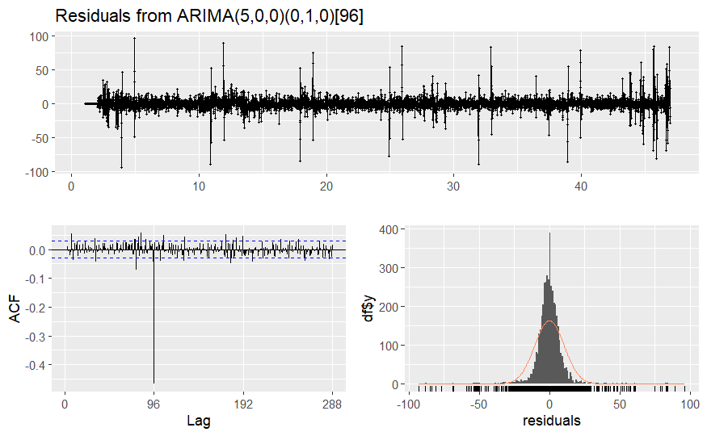

```r
# Vérification des résidus
checkresiduals(auto_arima)
```

En analysant les résidus, nous constatons que le modèle ne parvient pas à capturer toutes les autocorrélations significatives. Cela indique que certaines relations temporelles importantes dans la série ne sont pas correctement modélisées, ce qui peut limiter la précision des prévisions. Une optimisation supplémentaire des paramètres ou l’intégration de covariables pourrait améliorer ces performances.

## Modélisation - ARIMA Manuel

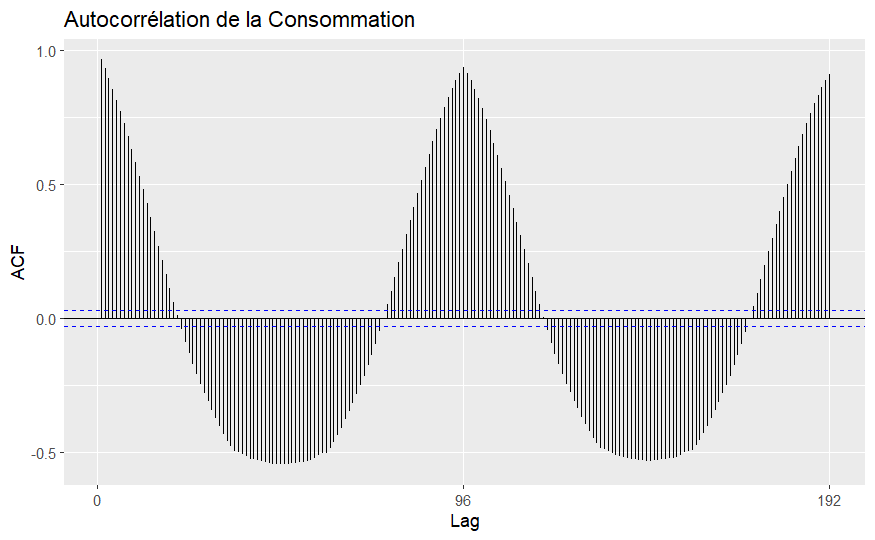

```r
# Inspection des autocorrélations
ggAcf(train_consumption_electricity, main = "Autocorrélation de la Consommation")
```

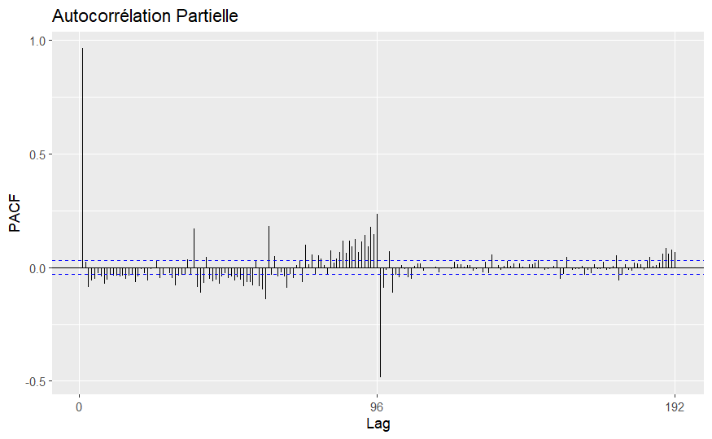

```r
ggPacf(train_consumption_electricity, main = "Autocorrélation Partielle")
```

```r
# Différenciation pour stationnarité
train_consumption_electricitydiff <- diff(diff(train_consumption_electricity, lag = 96))
plot(train_consumption_electricitydiff, main = "Différenciation Double (Saisonnalité et Tendances)")
```

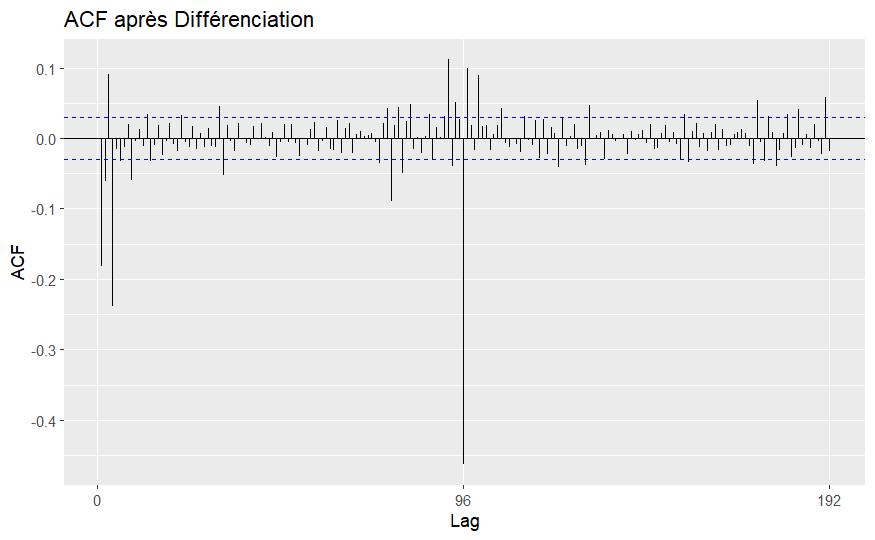

```r
# Autocorrélations après différenciation
ggAcf(train_consumption_electricitydiff, main = "ACF après Différenciation")
```

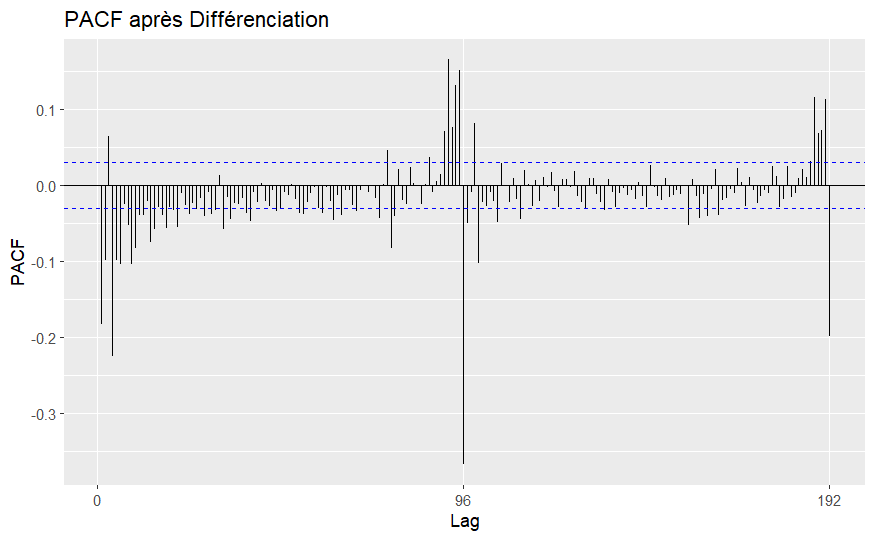

```r
ggPacf(train_consumption_electricitydiff, main = "PACF après Différenciation")
```

Nous avons appliqué une différenciation pour atteindre la stationnarité et une autre pour capturer la saisonnalité. En analysant l’ACF, nous observons un pic notable au lag 96, ce qui reflète une forte saisonnalité quotidienne (correspondant à une journée entière). De plus, le PACF présente des pics marqués aux lags 96, 192, etc., indiquant des corrélations significatives avec les jours précédents (1 jour, 2 jours, et ainsi de suite).

## Modélisation - SARIMA

```r
# Début de la mesure du temps d'exécution
start_time <- Sys.time()

# Ajustement manuel avec des paramètres affinés
sarima_refined <- Arima(
  train_consumption_electricity,
  order = c(5, 0, 0),
  seasonal = list(order = c(0, 1, 1), period = 96)
)

# Fin de la mesure du temps d'exécution
end_time <- Sys.time()

# Affichage des paramètres affinés
summary(sarima_refined)
```

```
Series: train_consumption_electricity
ARIMA(5,0,0)(0,1,1)[96]

Coefficients:
         ar1     ar2     ar3      ar4     ar5     sma1
      0.7027  0.0794  0.1134  -0.2350  0.1318  -0.8674
s.e.  0.0151  0.0182  0.0181   0.0182  0.0151   0.0085

sigma^2 = 63.56:  log likelihood = -15145.24
AIC=30304.49   AICc=30304.51   BIC=30349.07

Training set error measures:
                     ME     RMSE      MAE        MPE     MAPE      MASE         ACF1
Training set -0.3430878 7.880008 4.771361 -0.2426445 2.168773 0.5733068 -0.006097199
```

```
    Ljung-Box test

data:  Residuals from ARIMA(5,0,0)(0,1,1)[96]
Q* = 332.59, df = 186, p-value = 2.232e-10

Model df: 6.   Total lags used: 192
```

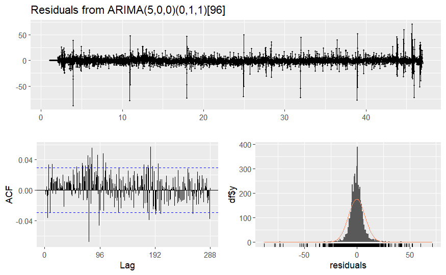

```r
# Vérification des résidus
checkresiduals(sarima_refined)
```

```r
# Prédictions sur l'ensemble de test
sarima_refined_forecast <- forecast(sarima_refined, h = 96)
rmse_sarima_refined <- sqrt(mean((test_consumption_electricity - sarima_refined_forecast$mean)^2))
cat("RMSE pour SARIMA Affiné:", rmse_sarima_refined, "\n")
```

```
RMSE pour SARIMA Affiné: 15.06212
```

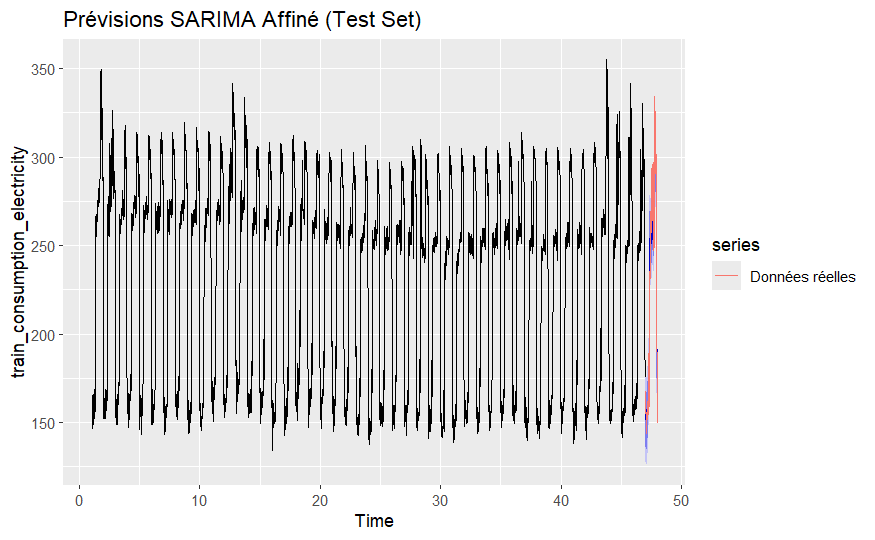

```r
# Visualisation
autoplot(sarima_refined_forecast, main = "Prévisions SARIMA Affiné (Test Set)") +
  autolayer(test_consumption_electricity, series = "Données réelles")
```

```r
# Calcul et affichage du temps total d'exécution
temps_total <- end_time - start_time
cat(sprintf("Temps total d'exécution : %.2f secondes\n", as.numeric(temps_total, units = "secs")))
```

```
Temps total d'exécution : 182.52 secondes
```

2eme modele manuel

```r
# Début de la mesure du temps d'exécution
start_time <- Sys.time()
sarima_manual <- Arima(
  train_consumption_electricity,
  order = c(1, 1, 1),
  seasonal = list(order = c(1, 1, 1), period = 96)
)
# Fin de la mesure du temps d'exécution
end_time <- Sys.time()
summary(sarima_manual)
```

```
Series: train_consumption_electricity
ARIMA(1,1,1)(1,1,1)[96]

Coefficients:
         ar1      ma1     sar1     sma1
      0.7246  -0.9866  -0.0568  -0.8697
s.e.  0.0118   0.0033   0.0181   0.0098

sigma^2 = 65.94:  log likelihood = -15228.11
AIC=30466.21   AICc=30466.23   BIC=30498.06

Training set error measures:
                   ME     RMSE      MAE         MPE     MAPE      MASE        ACF1
Training set 0.029245 8.026715 4.795688 -0.06737458 2.177461 0.5762298 -0.06244444
```

```r
# Calcul et affichage du temps total d'exécution
temps_total <- end_time - start_time
cat(sprintf("Temps total d'exécution : %.2f secondes\n", as.numeric(temps_total, units = "secs")))
```

```
Temps total d'exécution : 192.18 secondes
```

```r
# Prédictions et évaluation
sarima_forecast = forecast(sarima_manual, h = 96)
rmse_sarima <- sqrt(mean((test_consumption_electricity - sarima_forecast$mean)^2))
cat("RMSE pour ARIMA Manuel:", rmse_sarima, "\n")
```

```
RMSE pour ARIMA Manuel: 14.45752
```

Étant donné la taille relativement importante de notre jeu de données par rapport aux séries temporelles classiques, j’ai exploré l’utilisation d’un réseau de neurones récurrent (RNN) à travers l’algorithme nnetar.

### Entraînement et prévision

```r
# Démarrer le chronomètre
start_time <- Sys.time()

# Entraîner le modèle de réseau de neurones
rnn_model <- nnetar(train_consumption_electricity)
summary(rnn_model)
```

```
          Length Class        Mode
x         4411   ts           numeric
m            1   -none-       numeric
p            1   -none-       numeric
P            1   -none-       numeric
scalex       2   -none-       list
size         1   -none-       numeric
subset    4411   -none-       numeric
model       20   nnetarmodels list
nnetargs     0   -none-       list
fitted    4411   ts           numeric
residuals 4411   ts           numeric
lags        17   -none-       numeric
series       1   -none-       character
method       1   -none-       character
call         2   -none-       call
```

```r
# Prévision avec le modèle de réseau de neurones
rnn_forecast <- forecast(rnn_model, h = length(test_consumption_electricity))

# Arrêter le chronomètre
end_time <- Sys.time()
execution_time_rnn <- end_time - start_time
cat(sprintf("Temps d'exécution pour le modèle RNN : %.2f secondes\n", as.numeric(execution_time_rnn, units = "secs")))
```

```
Temps d'exécution pour le modèle RNN : 18.17 secondes
```

## Modélisation avec XGBoost

Après avoir exploré les modèles dédiés aux séries temporelles, j’ai opté pour l’utilisation d’un modèle d’apprentissage supervisé classique, XGBoost. Cependant, XGBoost n’est pas directement conçu pour traiter les séries temporelles. Pour surmonter cette limitation, j’ai transformé les données en créant des lags qui servent de variables explicatives. Ces lags permettent de capturer les dépendances temporelles et sont fournies au modèle comme entrées.

Pour aller au-delà des relations journalières et inclure des dynamiques hebdomadaires,j’ai choisi un max lag de 672 (correspondant à une semaine complète en quarts d’heure). Cette approche capture une quantité maximale d’informations pertinentes. J’ai également testé un max lag de 96 (une journée), mais les performances avec un lag de 672 se sont révélées meilleures

```r
# Préparation des données décalées

set.seed(42)
# Fonction pour créer les lags
create_lagged_data <- function(series, max_lag) {
  data <- data.frame(Target = series)
  for (lag in 1:max_lag) {
    data[[paste0("Lag", lag)]] <- lag(series, n = lag)
  }
  return(na.omit(data))
}

# Définition des paramètres
max_lag <- 672 # une semaine

# Création des lags pour les données sans covariables
lagged_data_no_covar <- create_lagged_data(as.numeric(c(train_consumption_electricity, test_consumption_electricity)), max_lag)

# Division en ensembles d'entraînement et de test
train_data_no_covar <- lagged_data_no_covar[1:(length(train_consumption_electricity) - max_lag), ]
test_data_no_covar <- lagged_data_no_covar[(length(train_consumption_electricity) - max_lag + 1):nrow(lagged_data_no_covar), ]

# Préparer les matrices pour XGBoost
train_matrix_no_covar <- as.matrix(train_data_no_covar[, -1])
test_matrix_no_covar <- as.matrix(test_data_no_covar[, -1])
train_target_no_covar <- train_data_no_covar$Target
test_target_no_covar <- test_data_no_covar$Target
```

```r
# Entraînement et prévision avec XGBoost

library(xgboost)

# Démarrer le chronomètre
start_time <- Sys.time()
# Création des DMatrix
dtrain_no_covar <- xgb.DMatrix(data = train_matrix_no_covar, label = train_target_no_covar)
dtest_no_covar <- xgb.DMatrix(data = test_matrix_no_covar, label = test_target_no_covar)

# Entraînement
xgb_model_no_covar <- xgb.train(
  params = list(
    objective = "reg:squarederror",
    eta = 0.1,
    max_depth = 6,
    subsample = 0.8,
    colsample_bytree = 0.8
  ),
  data = dtrain_no_covar,
  nrounds = 100,
  watchlist = list(train = dtrain_no_covar, test = dtest_no_covar),
  early_stopping_rounds = 10
)
```

[output not shown]

```r
# Arrêter le chronomètre
end_time <- Sys.time()
execution_time_xgb <- end_time - start_time
cat(sprintf("Temps d'exécution pour le modèle XGBoost : %.2f secondes\n", as.numeric(execution_time_xgb, units = "secs")))
```

```
Temps d'exécution pour le modèle XGBoost : 4.51 secondes
```

```r
# Évaluation et visualisation
# Prédictions
xgb_predictions_no_covar <- predict(xgb_model_no_covar, newdata = dtest_no_covar)

# Calcul du RMSE
rmse_no_covar <- sqrt(mean((test_target_no_covar - xgb_predictions_no_covar)^2))
cat("RMSE pour XGBoost sans covariables :", rmse_no_covar, "\n")
```

```
RMSE pour XGBoost sans covariables : 12.25804
```

# Analyse et Modélisation avec Covariables

Pour affiner les prédictions, j’ai décidé d’intégrer les données de température extérieure en tant que covariables dans les modèles. Cette démarche vise à inclure un facteur explicatif supplémentaire pouvant influencer la consommation électrique.

La première étape a consisté à analyser la relation et la corrélation entre la consommation électrique et la température.

### Visualisation des covariables

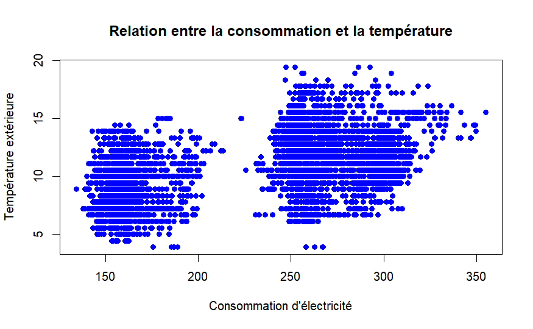

```r
# Tracer la consommation et la température extérieure
plot(data$electricity_consumption, data$outdoor_temperature,
     xlab = "Consommation d'électricité",
     ylab = "Température extérieure",
     main = "Relation entre la consommation et la température",
     col = "blue", pch = 16)
```

L’analyse initiale a révélé que la relation entre la température extérieure et la consommation d’énergie n’est pas strictement linéaire. Cela signifie que l’effet de la température sur la consommation peut varier en fonction des niveaux de température, ce qui nécessite l’exploration de modèles non linéaires, tels que des modèles quadratiques, pour mieux capturer cette dynamique.

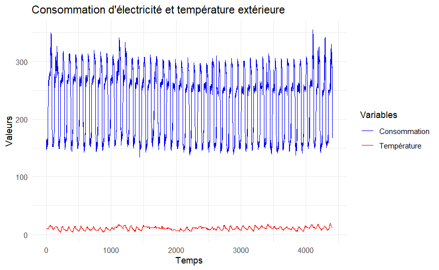

```r
# Création du data.frame pour ggplot
library(ggplot2)
plot_data <- data.frame(
  Timestamp = seq(from = 1, to = length(train_consumption_electricity)),  # Index temporel
  Consumption = as.numeric(train_consumption_electricity),
  Temperature = as.numeric(train_temperature_ts)
)

# Visualisation avec ggplot2
ggplot(plot_data, aes(x = Timestamp)) +
  geom_line(aes(y = Consumption, color = "Consommation")) +
  geom_line(aes(y = Temperature, color = "Température")) +
  scale_color_manual(
    name = "Variables",
    values = c("Consommation" = "blue", "Température" = "red")
  ) +
  labs(
    title = "Consommation d'électricité et température extérieure",
    x = "Temps",
    y = "Valeurs"
  ) +
  theme_minimal()
```

### Corrélation entre consommation et température

```r
# Calcul de la corrélation
correlation <- cor(plot_data$Consumption, plot_data$Temperature)
cat("Corrélation entre la consommation et la température :", correlation, "\n")
```

```
Corrélation entre la consommation et la température : 0.4764871
```

### Modèles linéaires et quadratiques

#### Modèle linéaire

```r
# Ajuster un modèle linéaire
lm_linear <- lm(electricity_consumption ~ outdoor_temperature, data = data)
summary(lm_linear)  # Résultat du modèle
```

```
Call:
lm(formula = electricity_consumption ~ outdoor_temperature, data = data)

Residuals:
     Min       1Q   Median       3Q      Max
-119.519  -41.833    1.767   42.731  114.710

Coefficients:
                    Estimate Std. Error t value Pr(>|t|)
(Intercept)         122.5753     3.0881   39.69   <2e-16 ***
outdoor_temperature  10.0544     0.2762   36.40   <2e-16 ***
---
Signif. codes:  0 ‘***’ 0.001 ‘**’ 0.01 ‘*’ 0.05 ‘.’ 0.1 ‘ ’ 1

Residual standard error: 50.6 on 4505 degrees of freedom
  (96 observations effacées parce que manquantes)
Multiple R-squared:  0.2273,    Adjusted R-squared:  0.2271
F-statistic:  1325 on 1 and 4505 DF,  p-value: < 2.2e-16
```

#### Modèle quadratique

```r
# Ajouter un terme quadratique pour la température
data$Temperature2 <- data$outdoor_temperature^2

# Ajuster un modèle quadratique
lm_quadratic <- lm(electricity_consumption ~ outdoor_temperature + Temperature2, data = data)
summary(lm_quadratic)
```

```
Call:
lm(formula = electricity_consumption ~ outdoor_temperature +
    Temperature2, data = data)

Residuals:
     Min       1Q   Median       3Q      Max
-118.979  -39.988    3.193   41.265  126.651

Coefficients:
                    Estimate Std. Error t value Pr(>|t|)
(Intercept)         66.92114    9.39991   7.119 1.26e-12 ***
outdoor_temperature 20.87816    1.74929  11.935  < 2e-16 ***
Temperature2        -0.49360    0.07878  -6.265 4.06e-10 ***
---
Signif. codes:  0 ‘***’ 0.001 ‘**’ 0.01 ‘*’ 0.05 ‘.’ 0.1 ‘ ’ 1

Residual standard error: 50.39 on 4504 degrees of freedom
  (96 observations effacées parce que manquantes)
Multiple R-squared:  0.234, Adjusted R-squared:  0.2336
F-statistic: 687.8 on 2 and 4504 DF,  p-value: < 2.2e-16
```

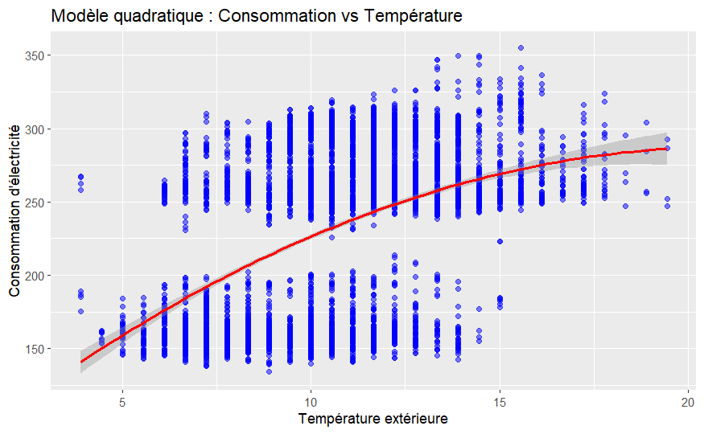

```r
# Visualisation
ggplot(data, aes(x = outdoor_temperature, y = electricity_consumption)) +
  geom_point(color = "blue", alpha = 0.5) +
  stat_smooth(method = "lm", formula = y ~ poly(x, 2), color = "red") +
  labs(
    title = "Modèle quadratique : Consommation vs Température",
    x = "Température extérieure",
    y = "Consommation d'électricité"
  )
```

#### Comparaison des modèles

```r
# Comparaison entre les modèles linéaire et quadratique
anova(lm_linear, lm_quadratic)
```

```
Analysis of Variance Table

Model 1: electricity_consumption ~ outdoor_temperature
Model 2: electricity_consumption ~ outdoor_temperature + Temperature2
  Res.Df      RSS Df Sum of Sq      F    Pr(>F)
1   4505 11534076
2   4504 11434416  1     99660 39.256 4.065e-10 ***
---
Signif. codes:  0 ‘***’ 0.001 ‘**’ 0.01 ‘*’ 0.05 ‘.’ 0.1 ‘ ’ 1
```

### Conclusion sur la relation quadratique

La p-valeur très petite (< 0.001) indique que le modèle quadratique explique significativement mieux la relation entre la consommation et la température que le modèle linéaire.

### Intégration des covariables dans ARIMA

#### Préparation des covariables

Pour capturer pleinement l’influence de la température sur la consommation d’énergie, j’ai ajouté la température extérieure et son carré (Température²) en tant que covariables. Ce choix permet de représenter à la fois les relations linéaires et non linéaires, offrant ainsi une meilleure modélisation des effets complexes de la température sur la consommation.

```r
# Ajouter le terme quadratique aux séries temporelles
train_temperature2_ts <- train_temperature_ts^2
test_temperature2_ts <- test_temperature_ts^2
forecast_temperature2_ts <- predict_temperature^2
```

#### Ajustement du modèle ARIMA avec covariables (température et température²)

```r
# Ajuster le modèle ARIMA avec covariables
fit_arima <- auto.arima(
  train_consumption_electricity,
  xreg = cbind(train_temperature_ts, train_temperature2_ts)
)

summary(fit_arima)
```

```
Series: train_consumption_electricity
Regression with ARIMA(5,0,0)(0,1,0)[96] errors

Coefficients:
         ar1     ar2     ar3      ar4     ar5  train_temperature_ts  train_temperature2_ts
      0.7149  0.0630  0.1068  -0.2614  0.1204               -1.6799                 0.1022
s.e.  0.0152  0.0182  0.0182   0.0183  0.0153                0.9787                 0.0437

sigma^2 = 112.4:  log likelihood = -16308.29
AIC=32632.58   AICc=32632.61   BIC=32683.53

Training set error measures:
                      ME     RMSE      MAE        MPE     MAPE      MASE         ACF1
Training set -0.05256004 10.47919 6.091059 -0.1223834 2.766989 0.7318762 -0.001377064
```

#### Prévisions et évaluation

```r
# Créer les matrices de covariables pour test et prévision
test_xreg <- cbind(test_temperature_ts, test_temperature2_ts)
forecast_xreg <- cbind(predict_temperature, forecast_temperature2_ts)

# Prévisions pour l'ensemble de test
forecast_test <- forecast(
  fit_arima,
  xreg = test_xreg
)
```

```r
# Calcul du RMSE
actual_test <- test_consumption_electricity
predicted_test <- forecast_test$mean
rmse_arima_covar_auto <- sqrt(mean((actual_test - predicted_test)^2))
cat("RMSE pour l'ensemble de test (ARIMA auto avec covariables) :", rmse_arima_covar_auto, "\n")
```

```
RMSE pour l'ensemble de test (ARIMA auto avec covariables) : 20.20766
```

## Ajustement du modèle TSLM avec covariables (température et température²)

Comme enseigné en cours, la première étape consiste à ajuster une régression linéaire (TSLM) avec les covariables pour capturer les tendances et les effets saisonniers. Ce modèle servira de base pour affiner et construire un meilleur modèle ARIMA avec covariables.

```r
# Ajuster le modèle tslm avec covariable
tslm_model <- tslm(
  train_consumption_electricity ~ train_temperature2_ts+ train_temperature_ts + trend + season
)

# Résumé du modèle
summary(tslm_model)
```

```
Call:
tslm(formula = train_consumption_electricity ~ train_temperature2_ts +
    train_temperature_ts + trend + season)

Residuals:
     Min       1Q   Median       3Q      Max
-113.254   -5.042    0.132    4.955   59.458

Coefficients:
                        Estimate Std. Error t value Pr(>|t|)
(Intercept)            1.661e+02  3.104e+00  53.523  < 2e-16 ***
train_temperature2_ts  1.167e-01  2.117e-02   5.514 3.71e-08 ***
train_temperature_ts  -1.247e+00  4.678e-01  -2.667  0.00769 **
trend                 -3.665e-03  1.503e-04 -24.380  < 2e-16 ***
season2               -5.850e+00  2.575e+00  -2.272  0.02315 *
season3                5.400e-02  2.575e+00   0.021  0.98327
season4                3.093e+00  2.575e+00   1.201  0.22970
season5                2.962e+00  2.561e+00   1.157  0.24754
season6               -6.189e+00  2.561e+00  -2.416  0.01571 *
season7               -6.353e+00  2.561e+00  -2.480  0.01316 *
season8               -3.029e+00  2.561e+00  -1.183  0.23694
season9               -3.582e+00  2.562e+00  -1.398  0.16207
season10              -7.982e-01  2.562e+00  -0.312  0.75536
season11              -1.832e+00  2.562e+00  -0.715  0.47468
season12              -3.257e-01  2.562e+00  -0.127  0.89884
season13              -4.715e+00  2.563e+00  -1.840  0.06582 .
season14              -6.097e+00  2.563e+00  -2.379  0.01740 *
season15              -5.624e-01  2.563e+00  -0.219  0.82629
season16               1.100e+00  2.563e+00   0.429  0.66777
season17               1.719e-01  2.564e+00   0.067  0.94655
season18              -7.440e-01  2.564e+00  -0.290  0.77171
season19               8.379e-01  2.564e+00   0.327  0.74384
season20               4.851e-01  2.564e+00   0.189  0.84996
season21               1.371e+00  2.565e+00   0.535  0.59299
season22               2.188e+00  2.565e+00   0.853  0.39374
season23               4.207e+00  2.565e+00   1.640  0.10109
season24               3.730e+00  2.565e+00   1.454  0.14599
season25               7.238e+00  2.565e+00   2.822  0.00480 **
season26               1.486e+01  2.565e+00   5.793 7.40e-09 ***
season27               1.616e+01  2.565e+00   6.302 3.23e-10 ***
```

[output cut: 60 more lines]

```
season88               1.308e+02  2.563e+00  51.044  < 2e-16 ***
season89               1.136e+02  2.562e+00  44.342  < 2e-16 ***
season90               1.118e+02  2.562e+00  43.634  < 2e-16 ***
season91               1.061e+02  2.562e+00  41.405  < 2e-16 ***
season92               1.065e+02  2.562e+00  41.567  < 2e-16 ***
season93               3.150e+01  2.561e+00  12.299  < 2e-16 ***
season94               3.312e+01  2.561e+00  12.932  < 2e-16 ***
season95               3.769e+00  2.561e+00   1.471  0.14124
season96               5.329e-01  2.575e+00   0.207  0.83606
---
Signif. codes:  0 ‘***’ 0.001 ‘**’ 0.01 ‘*’ 0.05 ‘.’ 0.1 ‘ ’ 1

Residual standard error: 12.21 on 4312 degrees of freedom
Multiple R-squared:  0.9559,    Adjusted R-squared:  0.9549
F-statistic: 952.7 on 98 and 4312 DF,  p-value: < 2.2e-16
```

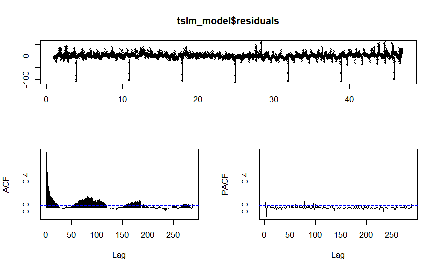

```r
tsdisplay(tslm_model$residuals)
```

```r
# Modèle SARIMA basé sur les résidus du modèle TSLM
sarima_model <- Arima(
  train_consumption_electricity,
  order = c(1, 0, 4),
  seasonal = list(order = c(1, 1, 1), period = 96),
  xreg = cbind(train_temperature_ts, train_temperature2_ts)  # Covariables
)

# Résumé du modèle SARIMA
summary(sarima_model)
```

```
Series: train_consumption_electricity
Regression with ARIMA(1,0,4)(1,1,1)[96] errors

Coefficients:
         ar1      ma1      ma2     ma3      ma4     sar1     sma1  train_temperature_ts
      0.8755  -0.1904  -0.0372  0.0708  -0.2201  -0.0538  -0.8522               -1.1881
s.e.  0.0226   0.0289   0.0227  0.0209   0.0214   0.0182   0.0102                0.9606
      train_temperature2_ts
                     0.0813
s.e.                 0.0431

sigma^2 = 63.16:  log likelihood = -15129.77
AIC=30279.54   AICc=30279.59   BIC=30343.24

Training set error measures:
                     ME    RMSE     MAE        MPE     MAPE      MASE        ACF1
Training set -0.3271188 7.85245 4.76945 -0.2364262 2.167988 0.5730772 0.002427306
```

```
    Ljung-Box test

data:  Residuals from Regression with ARIMA(1,0,4)(1,1,1)[96] errors
Q* = 298.44, df = 185, p-value = 2.447e-07

Model df: 7.   Total lags used: 192
```

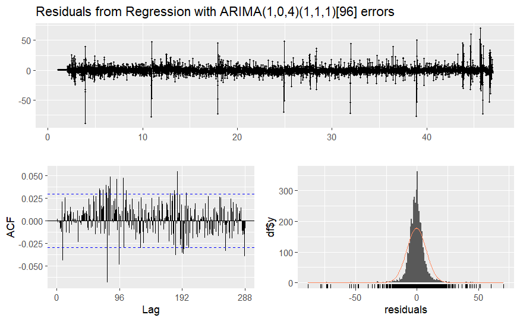

```r
# Diagnostic des résidus
checkresiduals(sarima_model)
```

```r
# Prévisions pour les données de test
sarima_forecast <- forecast(
  sarima_model,
  h = length(test_consumption_electricity),
  xreg = cbind(test_temperature_ts, test_temperature2_ts)  # Covariables pour les données de test
)
```

```r
# Visualisation des prévisions
plot(test_consumption_electricity, type = "l", col = "blue", lwd = 2,
     main = "Prévisions SARIMA avec covariables", ylab = "Consommation", xlab = "Temps")
lines(sarima_forecast$mean, col = "red", lwd = 2)
```

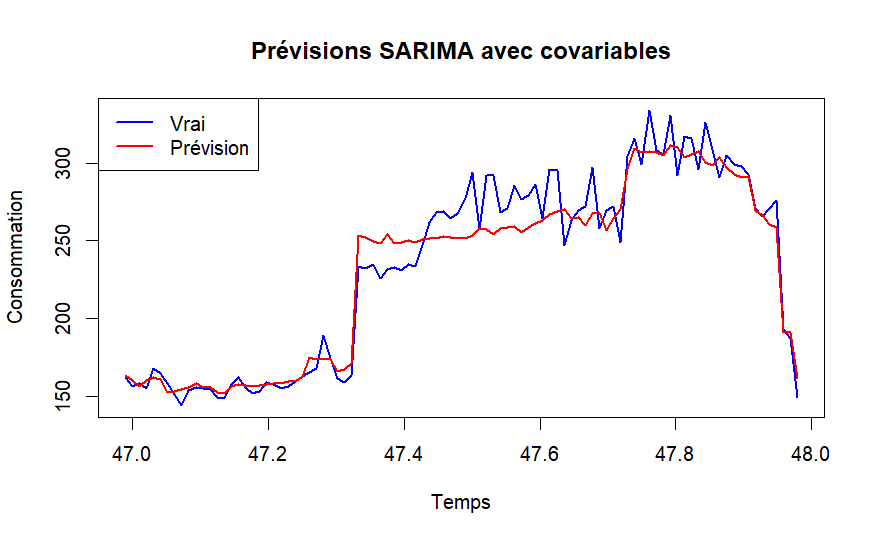

```r
legend("topleft", legend = c("Vrai", "Prévision"), col = c("blue", "red"), lty = 1, lwd = 2)
```

## Prévision RNN avec Réseau de Neurones et Covariables (température et température²)

```r
# Préparer les covariables pour l'entraînement
xreg_train <- cbind(
  Temperature = as.numeric(train_temperature_ts),
  Temperature2 = as.numeric(train_temperature_ts^2)
)
```

```r
fitt=nnetar(train_consumption_electricity,xreg=xreg_train)
print(fitt)
```

```
Series: train_consumption_electricity
Model:  NNAR(16,1,10)[96]
Call:   nnetar(y = train_consumption_electricity, xreg = xreg_train)

Average of 20 networks, each of which is
a 19-10-1 network with 211 weights
options were - linear output units

sigma^2 estimated as 63.05
```

```r
xreg_test <- cbind(
  Temperature = as.numeric(test_temperature_ts),
  Temperature2 = as.numeric(test_temperature_ts^2)
)
```

```r
prevNNcovar=forecast(fitt,xreg = xreg_test, h=96)
```

```r
RNN_covar = sqrt(mean((prevNNcovar$mean-test_consumption_electricity)^2))

cat("RMSE pour RNN avec covariables :", RNN_covar, "\n")
```

```
RMSE pour RNN avec covariables : 18.73548
```

## XGBoost avec covariable (température)

```r
# Fonction pour créer les lags avec covariables
create_lagged_data_with_covariate <- function(series, covariate, max_lag) {
  data <- data.frame(Target = series)
  for (lag in 1:max_lag) {
    data[[paste0("Lag", lag)]] <- lag(series, n = lag)
  }
  covariate_lagged <- covariate[(max_lag + 1):length(covariate)]
  data <- data[(max_lag + 1):nrow(data), ]
  data$Temperature <- covariate_lagged
  return(na.omit(data))
}

# Série complète avec température
full_series_covar <- c(train_consumption_electricity, test_consumption_electricity)
full_temperature_covar <- c(train_temperature_ts, test_temperature_ts)

# Création des lags avec covariables
lagged_data_covar <- create_lagged_data_with_covariate(as.numeric(full_series_covar), as.numeric(full_temperature_covar), max_lag)

# Division en ensembles d'entraînement et de test
train_data_covar <- lagged_data_covar[1:(length(train_consumption_electricity) - max_lag), ]
test_data_covar <- lagged_data_covar[(length(train_consumption_electricity) - max_lag + 1):nrow(lagged_data_covar), ]

# Préparer les matrices pour XGBoost
train_matrix_covar <- as.matrix(train_data_covar[, -1])
test_matrix_covar <- as.matrix(test_data_covar[, -1])
train_target_covar <- train_data_covar$Target
test_target_covar <- test_data_covar$Target
```

```r
start_time <- Sys.time()
# Création des DMatrix
dtrain_covar <- xgb.DMatrix(data = train_matrix_covar, label = train_target_covar)
dtest_covar <- xgb.DMatrix(data = test_matrix_covar, label = test_target_covar)

# Entraînement
xgb_model_covar <- xgb.train(
  params = list(
    objective = "reg:squarederror",
    eta = 0.1,
    max_depth = 6,
    subsample = 0.8,
    colsample_bytree = 0.8
  ),
  data = dtrain_covar,
  nrounds = 100,
  watchlist = list(train = dtrain_covar, test = dtest_covar),
  early_stopping_rounds = 10
)
```

[output not shown]

```r
# Prédictions
xgb_predictions_covar <- predict(xgb_model_covar, newdata = dtest_covar)

# Calcul du RMSE
rmse_covar <- sqrt(mean((test_target_covar - xgb_predictions_covar)^2))
cat("RMSE pour XGBoost avec covariables :", rmse_covar, "\n")
```

```
RMSE pour XGBoost avec covariables : 12.13472
```

```r
end_time <- Sys.time()
temps_total <- end_time - start_time
cat(sprintf("Temps total d'exécution : %.2f secondes\n", as.numeric(temps_total, units = "secs")))
```

```
Temps total d'exécution : 4.50 secondes
```

# Résumé des Performances

```r
# Tableau des RMSE
model_names <- c(
  "Régression Linéaire",
  "SES",
  "Holt",
  "Holt-Winters Additif",
  "Holt-Winters Multiplicatif",
  "ARIMA Auto Sans Covariables",
  "ARIMA Manuel Sans Covariables",
  "ARIMA Raffiné Sans Covariables",
  "RNN Sans Covariables",
  "XGBoost Sans Covariables",
  "ARIMA Auto avec Covariables",
  "ARIMA avec Covariables (Manuel)",
  "RNN avec Covariables",
  "XGBoost avec Covariables"
)

rmse_values <- c(
  rmse_linear,
  rmse_ses,
  rmse_holt,
  rmse_hw_add,
  rmse_hw_mult,
  rmse_arima,
  rmse_sarima,
  rmse_sarima_refined,
  rnn_rmse,
  rmse_no_covar,
  rmse_arima_covar_auto,
  sarima_with_covariate_rmse_man,
  RNN_covar,
  rmse_covar
)

results <- data.frame(
  Modèle = model_names,
  RMSE = rmse_values
)

# Affichage du tableau
print(results)
```

| Modèle | RMSE |
| --- | --- |
| Régression Linéaire | 61.31617 |
| SES | 88.88736 |
| Holt | 88.82056 |
| Holt-Winters Additif | 16.86543 |
| Holt-Winters Multiplicatif | 13.92376 |
| ARIMA Auto Sans Covariables | 19.78907 |
| ARIMA Manuel Sans Covariables | 14.45752 |
| ARIMA Raffiné Sans Covariables | 15.06212 |
| RNN Sans Covariables | 18.05599 |
| XGBoost Sans Covariables | 12.25804 |

[output cut: 4 more lines]

En se basant sur les résultats, le modèle XGBoost s’avère être le meilleur, que ce soit avec ou sans covariables, en termes de RMSE. Il obtient un RMSE de 12,25 sans covariable et de 12,13 avec covariable.

# affichage des courbes des prévisions des meilleurs modèles obtenus

```r
# Fusionner les données d'entraînement, de test et les prédictions futures
full_series_no_covar <- c(train_target_no_covar, test_target_no_covar, xgb_predictions_no_covar)

# Création des phases pour le graphique
phases_no_covar <- c(
  rep("Entraînement", length(train_target_no_covar)),
  rep("Test", length(test_target_no_covar)),
  rep("Prédictions Futures", length(xgb_predictions_no_covar))
)

# Afficher le graphique
plot(full_series_no_covar, type = "l", col = "black", xlab = "Temps", ylab = "Consommation",
     main = "Prédictions XGBoost Sans Covariable : Entraînement, Test et Prévisions Futures")

# Ajouter les phases avec des couleurs différentes
lines(1:length(train_target_no_covar), train_target_no_covar, col = "blue")
```

```r
lines((length(train_target_no_covar) + 1):(length(train_target_no_covar) + length(test_target_no_covar)),
      test_target_no_covar, col = "green")
lines((length(train_target_no_covar) + length(test_target_no_covar) + 1):length(full_series_no_covar),
      xgb_predictions_no_covar, col = "red")
```

[figure not shown]

```r
# Ajouter une légende
legend("topleft", legend = c("Entraînement", "Test", "Prédictions Futures"),
       col = c("blue", "green", "red"), lty = 1)
```

```r
# Fusionner les données d'entraînement, de test et les prédictions futures
full_series_covar <- c(train_target_covar, test_target_covar, xgb_predictions_covar)

# Création des phases pour le graphique
phases_covar <- c(
  rep("Entraînement", length(train_target_covar)),
  rep("Test", length(test_target_covar)),
  rep("Prédictions Futures", length(xgb_predictions_covar))
)

# Afficher le graphique
plot(full_series_covar, type = "l", col = "black", xlab = "Temps", ylab = "Consommation",
     main = "Prédictions XGBoost Avec Covariable : Entraînement, Test et Prévisions Futures")

# Ajouter les phases avec des couleurs différentes
lines(1:length(train_target_covar), train_target_covar, col = "blue")
```

```r
lines((length(train_target_covar) + 1):(length(train_target_covar) + length(test_target_covar)),
      test_target_covar, col = "green")
lines((length(train_target_covar) + length(test_target_covar) + 1):length(full_series_covar),
      xgb_predictions_covar, col = "red")
```

[figure not shown]

```r
# Ajouter une légende
legend("topleft", legend = c("Entraînement", "Test", "Prédictions Futures"),
       col = c("blue", "green", "red"), lty = 1)
```

```r
forecast_df <- data.frame(
  xgb_predictions_no_covar,
  xgb_predictions_covar
)
```

```r
head(forecast_df)
```

|  | xgb_predictions_no_covar | xgb_predictions_covar |
| --- | --- | --- |
| 1 | 159.3158 | 161.2770 |
| 2 | 152.1574 | 156.5763 |
| 3 | 154.8108 | 155.9747 |
| 4 | 157.2654 | 157.9379 |
| 5 | 157.0019 | 156.7480 |
| 6 | 162.4443 | 164.2332 |

```r
library(writexl)

# Sauvegarder dans un fichier Excel
write_xlsx(forecast_df, path = "Jomaa.xlsx", col_names = FALSE)
cat("Les prévisions ont été sauvegardées dans 'Jomaa.xlsx'\n")
```

```
Les prévisions ont été sauvegardées dans 'Jomaa.xlsx'
```